# softImpute

Jakub Kosterna, Dawid Przybyliński, Hanna Zdulska

25 marca 2020

# 1 Wprowadzenie

## 1.1 Geneza i zawartość

SoftImpute to nieduży i przydatny pakiet do uzupełniania macierzy, stworzony przez Trevor Hastiego (Stanford, autor wielu książek o statystyce). Wykorzystuje do tego **nuclear norm regularization**, znanej także jako **trace norm regularization** (pl: *regularyzacja norm śladowych*). Biblioteka implementuje:

- funkcję *softImpute()* z dwoma przydatnymi algorytmami:
  1. Iteracyjne obliczenie soft-thresholded SVD z wypełnionej macierzy (opcja *type=“svd”*)
  2. Uzupełnianie braków ramki szacunkami korzystając z alternating ridge regression (zwane popularniej w Europie *Tikhonov regularization*) (opcja *type=“als”*)
- *biscale()* - zoptymalizowane scale() działające również na niekompletnej macierzy, działające też szybko na bardzo dużych macierzach
- dwie nowe klasy dla macierzy: *SparseplusLowRank* i *Incomplete*

## 1.2 Zalety i wady

Pakiet z założenia służy do uzupełniania macierzy, wymaga on nas konwersji z data.frame na klasę matrix. Operuje tylko na macierzach, co jest równocześnie zaletą - potrzebuje tylko pakiet Matrix:

```r
require(deepdep)
```

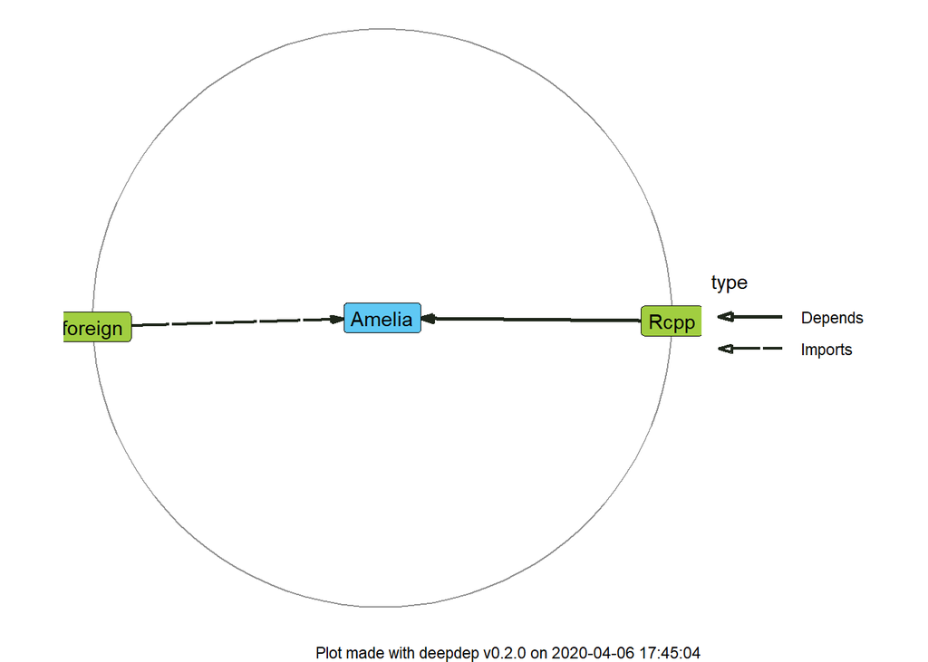

```r
plot_dependencies(deepdep("Amelia", depth = 2))
```

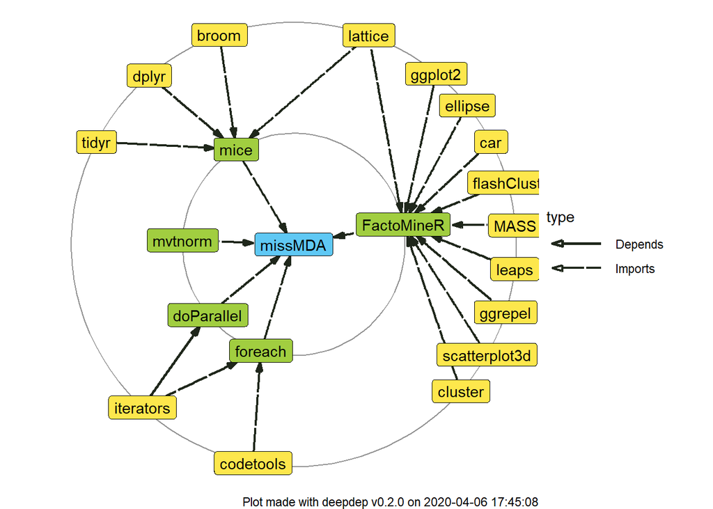

```r
plot_dependencies(deepdep("missMDA", depth = 2))
```

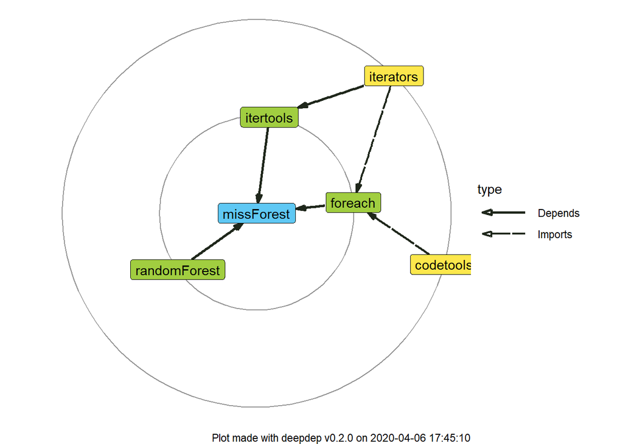

```r
plot_dependencies(deepdep("missForest", depth = 2))
```

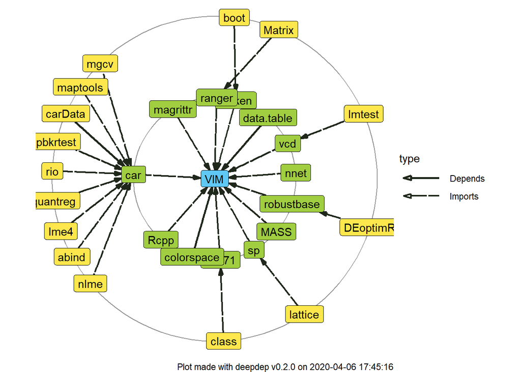

```r
plot_dependencies(deepdep("VIM", depth = 2))
```

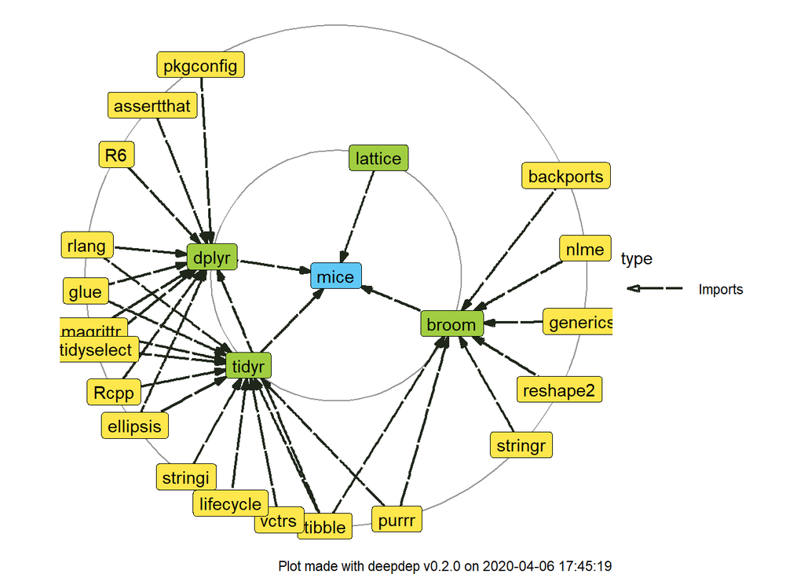

```r
plot_dependencies(deepdep("mice", depth = 2))
```

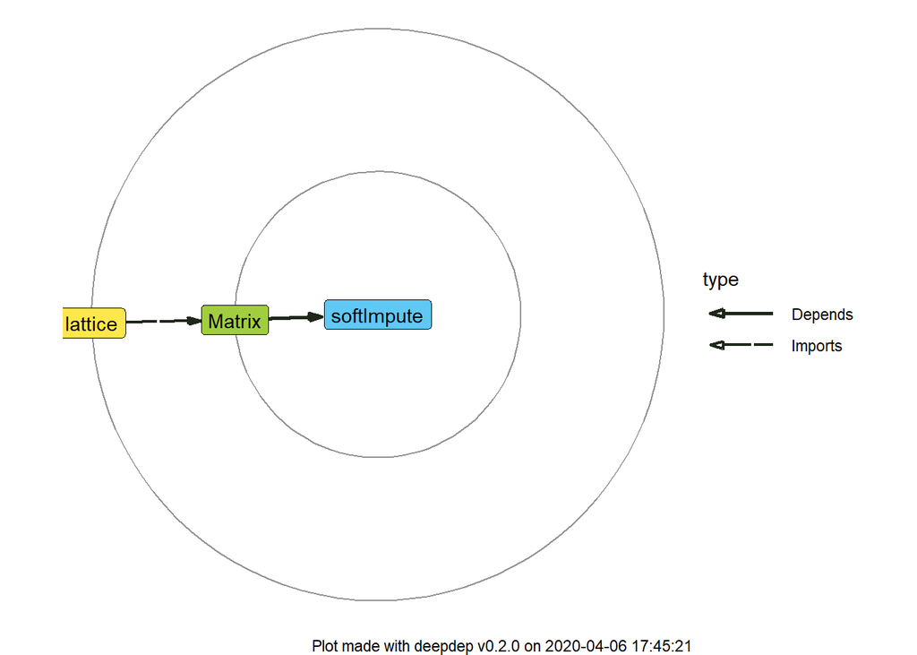

```r
plot_dependencies(deepdep("softImpute", depth = 2))
```

Zaletą pakietu jest fakt, że może obsługiwać zarówno małe, jak i bardzo duże macierze w relatywnie krótkim czasie, dzięki użyciu klasy Incomplete. Dla przykładu `softImpute` bez problemu dopasuje macierz rzędu 100 do danych Netflixa (480,189 użytkowników x 17,770 filmów co daje około 8.6 * 10^9 obserwacji, przy czym średnio jeden użytkownik ocenia tylko 200 filmów, co daje tylko 1.2% obserwacji ~10^8) w 3.3h

# 2 Jak działa algorytm?

## 2.1 Soft-thresholded SVD

Niech $X$ będzie dużą $m\times n$ macierzą z wiloma brakującymi wartościami. Niech $\Omega$ zawiera pary indeksów $(i,j)$ gdzie $X$ był zaobserwowany, i niech $P_\Omega(X)$ oznacza macierz z wartościami jak w $X$ w punktach z $\Omega$, a w pozostałych ma wartości 0. Zatem jeśli $X$ ma brakujące wartości w $\Omega^\perp$, $P_\Omega(X)$ by oznaczyło NA jako 0.

Rozważmy wyrażenie
$$\min_M\frac12\|P_\Omega(X)-M\|^2_F+\lambda\|M\|_*,$$
gdzie $\|M\|_*$ to suma wartości singularnych macierzy $M$ (nucelar norm, trace norm), natomiast $\lambda$ jest parametrem.

Niech $\widehat M$ będzie przybliżeniem rozwiązania problemu:
$$Z=P_\Omega(X)+P_{\Omega^\perp}(\widehat M).$$

$${\widehat M}=S_\lambda(Z)$$

Operator $S_\lambda(Z)$ dla macierzy $Z$ wykonuje następujące instrukcje:

1. Znajduje rozkład SVD dla $Z=UDV$, oraz $d_i$ - wartości singularne $Z$.
2. Zaszumia wartości singularne: $d_i^*= (d_i-\lambda)_+$.
3. Tworzy nową macierz $Z$: $S_\lambda(Z)=UD^*V$. Dla dostaecznie dużych wartości $\lambda$, $D^*$ będzie miało zmniejszony rząd, więc również i $UD^*V$.

Stąd tworząc kolejne macierze ${\widehat M}$, dostajemy algorytm iteracyjny.

## 2.2 Rozkład SVD

Każdą macierz A można przedstawić jako:

$$A = UDV$$
gdzie:

$U, V$ - macierze ortogolnalne

$D$ - macierz diagonalna złożona z wartości singularnych $A$

# 3 Działanie

## 3.1 Odczyt

```r
# install.packages("softImpute") # if not installed
library(softImpute)
```

## 3.2 Przykłady

UWAGA! Tylko wartości numeryczne.

```r
softImpute(matrix(c('a', 'b', 'a', NA, 'c', 'b'), 2, 3))
```

Wywołanie powyższej linii kodu zwróciłoby błąd.

### 3.2.1 Ogląd na prostej macierzy

Wpierw w celu obycia ze składnią przetestujmy wpierw naszą podstawową funkcję na losowej macierzy 5 x 6 z wartościami z rozkładu normalnego i usuńmy z niej losowe 7 wartości.

```r
set.seed(17)

X = matrix(rnorm(30), 5, 6)
X_del = X
X_del[sample(1:30, 7, replace = FALSE)] = NA
X_del
```

```
##            [,1]       [,2]      [,3]        [,4]       [,5]       [,6]
## [1,] -1.0150087 -0.1656119        NA -0.05517906  0.6810276  1.1598438
## [2,]         NA  0.9728744 0.6431921  0.83847112 -0.6820334  0.1174224
## [3,] -0.2329870  1.7165340        NA          NA         NA  0.2592214
## [4,] -0.8172679  0.2552370        NA  0.62595440  1.6735260  0.3823621
## [5,]  0.7720908  0.3665811 1.5912051          NA -0.5957556 -0.7114817
```

Utworzymy zmienną *fits* generującą dopasowanie w zależności od macierzy z usuniętymi wartościami, a następnie wypełnimy ją z pomocą funkcji *complete()*.

```r
fits <- softImpute(X_del, trace = TRUE, type = "svd")
```

```
## 1 : obj 0.05672 ratio 0.03107992
## 2 : obj 0.04188 ratio 0.009986207
## 3 : obj 0.036 ratio 0.004542199
## 4 : obj 0.03296 ratio 0.002482455
## 5 : obj 0.03115 ratio 0.001527719
## 6 : obj 0.02996 ratio 0.001022953
## 7 : obj 0.02912 ratio 0.0007301109
## 8 : obj 0.0285 ratio 0.0005478809
## 9 : obj 0.02802 ratio 0.0004279884
## 10 : obj 0.02763 ratio 0.0003454006
## 11 : obj 0.02731 ratio 0.000286249
## 12 : obj 0.02704 ratio 0.0002424275
## 13 : obj 0.02681 ratio 0.000208984
## 14 : obj 0.02661 ratio 0.0001827781
## 15 : obj 0.02643 ratio 0.0001617558
```

[output cut: 58 more lines]

```r
completed <- complete(X_del, fits)
```

Zobaczmy macierz wejściową, wypełnioną, ich różnicę i miarę rmse.

```r
X
```

```
##             [,1]       [,2]      [,3]        [,4]       [,5]       [,6]
## [1,] -1.01500872 -0.1656119 1.1807892 -0.05517906  0.6810276  1.1598438
## [2,] -0.07963674  0.9728744 0.6431921  0.83847112 -0.6820334  0.1174224
## [3,] -0.23298702  1.7165340 1.2953219  0.15937013 -0.7232567  0.2592214
## [4,] -0.81726793  0.2552370 0.1879181  0.62595440  1.6735260  0.3823621
## [5,]  0.77209084  0.3665811 1.5912051  0.63358473 -0.5957556 -0.7114817
```

```r
completed
```

```
##            [,1]       [,2]       [,3]        [,4]       [,5]       [,6]
## [1,] -1.0150087 -0.1656119 -1.9997203 -0.05517906  0.6810276  1.1598438
## [2,]  0.4388203  0.9728744  0.6431921  0.83847112 -0.6820334  0.1174224
## [3,] -0.2329870  1.7165340 -1.0268945  1.81724627  0.5552696  0.2592214
## [4,] -0.8172679  0.2552370 -2.4074339  0.62595440  1.6735260  0.3823621
## [5,]  0.7720908  0.3665811  1.5912051  0.20263527 -0.5957556 -0.7114817
```

```r
X - completed
```

```
##           [,1] [,2]     [,3]       [,4]      [,5] [,6]
## [1,]  0.000000    0 3.180510  0.0000000  0.000000    0
## [2,] -0.518457    0 0.000000  0.0000000  0.000000    0
## [3,]  0.000000    0 2.322216 -1.6578761 -1.278526    0
## [4,]  0.000000    0 2.595352  0.0000000  0.000000    0
## [5,]  0.000000    0 0.000000  0.4309495  0.000000    0
```

```r
# install.packages("Metrics") # if not installed
library(Metrics)
rmse(X, completed)
```

```
## [1] 0.9501207
```

### 3.2.2 Metoda regularna

W kolejnych krokach będziemy rozpatrywać macierz wygenerowaną w bardziej złożony sposób zawierającą już pewne nie-zupełnie-losowe własności matematyczne. Wpierw przygotujmy ją i usuńmy 30% wartości.

```r
set.seed(101)
n <- 200
p <- 100
J <- 50
np <- n * p
missfrac <- 0.3

x <- matrix(rnorm(n*J), n, J) %*% matrix(rnorm(J*p), J, p) + matrix(rnorm(np), n, p) / 5
sample(x, 20)
```

```
##  [1]   3.1356125  -5.0314127  14.6420110   2.1717486   3.7154134
##  [6]  10.7513543 -10.4458655   4.6172150  -0.1606346  -2.0076311
## [11]  -0.5253783  -7.5956759  -3.0030934  -6.4953961  -8.3989026
## [16]  -5.4860716  -9.1226877  -2.6376701 -11.6181502  -2.5573694
```

```r
ix <- seq(np)
imiss <- sample(ix, np*missfrac, replace=FALSE)
xna <- x
xna[imiss] = NA
```

Przygotujemy także dwie maierze pomocnicze - *xMeans* i *xZeros* odpowiadające za matryce uzupełnione odpowiedni średnimi i zerami. Porównanie miar rezultatu *softImpute()* i owych dwóch da nam dobry ogląd jakości naszej funkcji.

```r
xZeros <- xna
xZeros[is.na(xZeros)] <- 0
sample(xZeros, 10)
```

```
##  [1]  0.0000000 -0.2808846  7.9832052  7.2718747  6.6545192 -6.7467766
##  [7] -5.7728270 -5.6146352 -7.5953992  5.7163836
```

```r
Xmean <- mean(xZeros) * 10 / 7
print(Xmean)
```

```
## [1] 0.1014247
```

```r
xMeans <- xna
xMeans[is.na(xMeans)] <- Xmean
sample(xMeans, 10)
```

```
##  [1] -1.8027705  8.4900993 -6.3677717  2.0138202 -7.5836865  7.1147630
##  [7]  7.9447159  0.1014247  1.5422816  3.6424018
```

Metoda “klasyczna”

```r
### uses regular matrix method for matrices with NAs
fit1 <- softImpute(xna, rank = 50, lambda = 30)
```

W efekcie otrzymujemy 3 macierze:

1. fit1$u odpowiada za $U$
2. fit1$v odpowiada za $V$
3. fit1$d odpowiada za $\Sigma$

…gdzie:

- ${\displaystyle A=U\Sigma V^{T},}$
- $U$ i $V$ – macierze ortogonalne (czyli ${\displaystyle U^{-1}=U^{T},}{\displaystyle U^{-1}=U^{T},} {\displaystyle V^{-1}=V^{T}}V^{-1}=V^T)$
- $\Sigma$ – macierz diagonalna (przekątniowa), taka że ${\displaystyle \Sigma =\operatorname {diag} (\sigma _{i}),}{\displaystyle \Sigma =\operatorname {diag} (\sigma _{i}),}$ gdzie ${\displaystyle \sigma _{i}}\sigma _{i}$ – nieujemne wartości szczególne (osobliwe) macierzy ${\displaystyle A,}A$, zwyczajowo uporządkowane nierosnąco.

```
## [1] "Wymiary V:"
```

```
## [1] 100  50
```

```
## [1] "Wymiary U:"
```

```
## [1] 200  50
```

```
## [1] "Wartości macierzy diagonalnej:"
```

```
##  [1] 207.197015 188.763175 184.121555 169.136377 162.739021 159.955459
##  [7] 153.996732 146.713530 140.520580 135.721597 127.127066 125.946379
## [13] 123.386031 117.613769 107.703547 104.253393  98.839062  95.980279
## [19]  92.976762  88.848980  83.793139  81.274324  80.058699  76.970666
## [25]  71.154179  68.537962  63.726437  61.894521  58.515818  56.309026
## [31]  52.001528  49.880237  45.168583  42.085577  39.614018  37.187463
## [37]  34.978034  31.785349  30.416430  25.421637  22.371432  21.750776
## [43]  19.308268  16.561394  13.922365  10.062491   5.637020   4.222932
## [49]   2.636285   1.889479
```

Zobaczmy czy zaiste wygenerowane macierze spełniają warunek rozkładu SVD i średni błąd kwadratowy macierzy wejściowej i wygenerowanej przez *softImpute()*:

```r
result <- (fit1$u * fit1$d) %*% t(fit1$v)
rmse(result, x)
```

```
## [1] 5.008946
```

```r
rmsM <- rmse(x, xMeans)
rmsM
```

```
## [1] 3.853061
```

```r
rms0 <- rmse(x, xZeros)
rms0
```

```
## [1] 3.852114
```

W porównaniu do macierzy wejściowej uzupełnionej zerami i średnimi tak średnio bym powiedział. Ale w końcu robotę robi funkcja *complete()* - która uzupełnia braki macierzy wejściowej tymi z tej specjalnie generowanej. Oczywiście im mniejszy błąd - tym lepszy będzie rezultat. Ale czy aż dla 30% funkcja ogarnie coś sensownego?

Satysfakcjonująco! A jak poradzi sobie funkcja *complete()*?

```r
completed <- complete(xna, fit1)
rms1 <- rmse(x, completed)
rms1
```

```
## [1] 2.385498
```

Jak widać jak najbardziej! 30% brakujących wartości zostało uzupełnionych i wynik wyszedł zdecydowanie lepszy niż dla uzupełniania zerami czy średnimi.

### 3.2.3 Dla klasy *Incomplete*

W dalszej kolejności efekt działania klasy *Incomplete* z użytkiem macierzy rzadkich.

```r
### uses sparse matrix method for matrices of class "Incomplete"
xnaC <- as(xna, "Incomplete")
fit2 <- softImpute(xnaC, rank=50, lambda=30)
```

```
## [1] "Wymiary V:"
```

```
## [1] 100  50
```

```
## [1] "Wymiary U:"
```

```
## [1] 200  50
```

```r
result <- (fit2$u * fit2$d) %*% t(fit2$v)
rmse(result, x)
```

```
## [1] 5.002223
```

```r
completed <- complete(xna, fit2)
rms2 <- rmse(x, completed)
rms2
```

```
## [1] 2.382392
```

### 3.2.4 Algorytm *svd*

… czyli iteracyjne obliczanie *soft-thresholded SVD* z wypełnionej macierzy.

```r
### uses "svd" algorithm
fit3 <- softImpute(xnaC, rank=50, lambda=30, type="svd")

result <- (fit3$u * fit3$d) %*% t(fit3$v)
rmse(result, x)
```

```
## [1] 5.015988
```

```r
completed <- complete(xna, fit3)
rms3 <- rmse(x, completed)
rms3
```

```
## [1] 2.389274
```

### 3.2.5 biScale()

Całkiem ładny wynik. Zobaczmy jeszcze *softImpute()* z użyciem *biScale()*.

```r
### first scale xna
xnas <- biScale(xna)
```

Czy faktycznie nasza macierz została poprawnie przeskalowana?

```r
mean(xnas[!is.na(xnas)])
```

```
## [1] -2.154389e-16
```

```r
var(xnas[!is.na(xnas)])
```

```
## [1] 1.000071
```

Wszystko jest w porządku! Średnia wyszła niemalże 0, a wariancja - niemalże 1. Otrzymaliśmy więc poprawne przeskalowanie.

```r
fit4 <- softImpute(xnas, rank=50, lambda=10)
completed <- complete(xna, fit4)
rms4 <- rmse(x, completed)
rms4
```

```
## [1] 3.106461
```

### 3.2.6 impute() pod lupą

Możemy też przyjrzeć się lepiej temu co siedzi pod *complete()* wyświetlając efekt samej funkcji *impute()*, z której *complete()* korzysta.

W dokumentacji czytamy: *impute returns a vector of predictions, using the reconstructed low-rank matrix representation represented by object. It is used by complete, which returns a complete matrix with all the missing values imputed.*

```r
impute(fit4, i = c(1, 3, 7), j = c(2, 5, 10))
```

```
## [1]  3.725617 -2.741480 -2.178714
```

```r
impute(fit4, i = c(1, 3, 7), j = c(2, 5, 10), unscale = FALSE) # ignore scaling and centering
```

```
## [1]  0.5852387 -0.5708038 -0.2386016
```

### 3.2.7 Podsumowanie

Na dobry koniec porównajmy jeszcze miary błędów średniokwadratowych dla zaproponowanych metod imputacji macierzy:

```r
summary <- data.frame(rms1, rms2, rms3, rms4)
colnames(summary) <- c("regular", "macierze rzadkie + incomplete", "svd", "z bi-skalowaniem")
summary
```

| regular | macierze rzadkie + incomplete | svd | z bi-skalowaniem |
| --- | --- | --- | --- |
| 2.385498 | 2.382392 | 2.389274 | 3.106461 |

```r
zerosMeans <- data.frame(rms0, rmsM)
colnames(zerosMeans) <- c("zeros", "means")
zerosMeans
```

| zeros | means |
| --- | --- |
| 3.852114 | 3.853061 |

Sukces!

# 4 Bibliografia - poczytaj wiecej

- [Mazumder et al (2010)](http://web.stanford.edu/~hastie/Papers/mazumder10a.pdf)
- [Hastie et al (2014)](http://arxiv.org/abs/1410.2596)